# Examining Carbon Correlations and California Wild

## California Wildfires

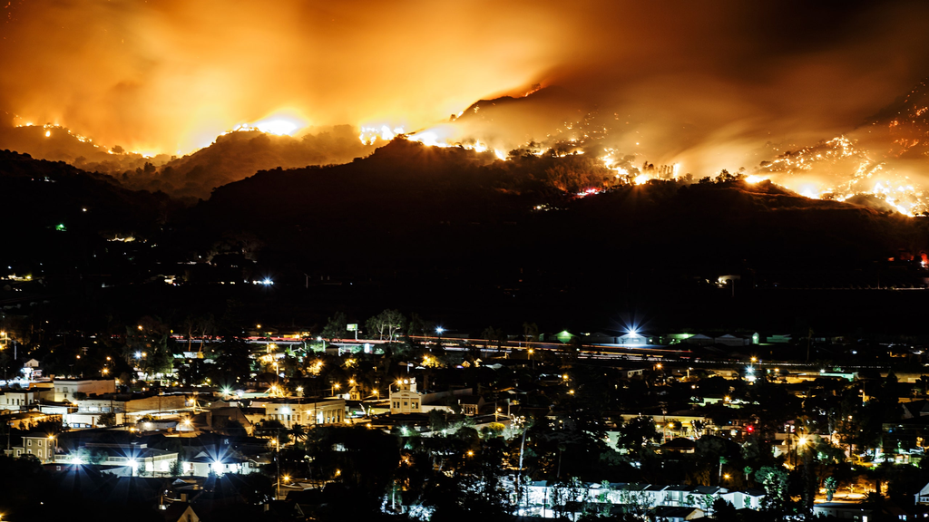

We next examine the wildfires in California.

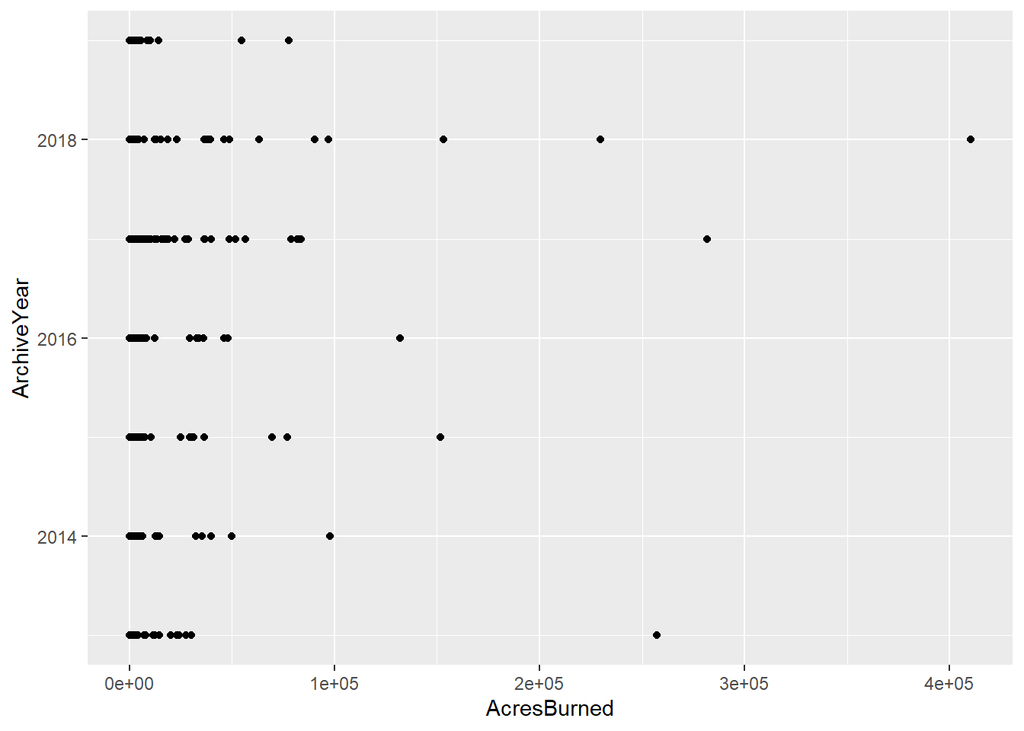

```r
California_Fire <- California_Fire_Incidents <- read.csv("C:/Users/Wilson Bao/Desktop/CO2 Data/California_Fire_Incidents.csv")
California_Fire2 <- select(California_Fire, AcresBurned, ArchiveYear)
ggplot(California_Fire2, aes(x=AcresBurned, y= ArchiveYear)) + geom_point()
```

```r
yearsAcres <- select(California_Fire_Incidents, AcresBurned, ArchiveYear)
head(yearsAcres)
```

|  | AcresBurned | ArchiveYear |
| --- | --- | --- |
| 1 | 257314 | 2013 |
| 2 | 30274 | 2013 |
| 3 | 27531 | 2013 |
| 4 | 27440 | 2013 |
| 5 | 24251 | 2013 |
| 6 | 22992 | 2013 |

And as seen in this bar graph, the number of acres burned had a large uptick in 2017 and 2018. Before 2017, the number of acres burned stabilized around 500,000. Since then, the problem of wildfires has only increased, and it is imperative that protective measures be put in place to stop this trend.

```r
str(yearsAcres)
```

```
## 'data.frame':    1636 obs. of  2 variables:
##  $ AcresBurned: int  257314 30274 27531 27440 24251 22992 20292 14754 12503 11429 ...
##  $ ArchiveYear: int  2013 2013 2013 2013 2013 2013 2013 2013 2013 2013 ...
```

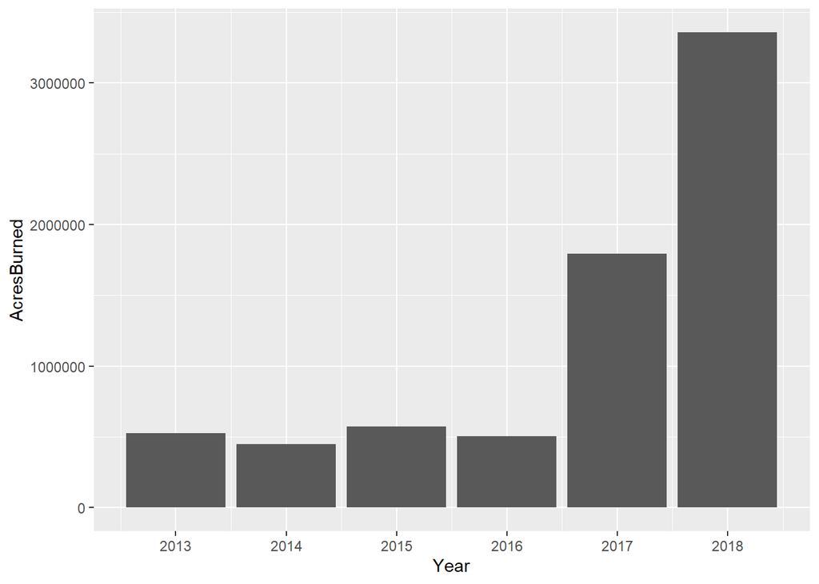

```r
yearsAcres2 <- as.factor(yearsAcres$ArchiveYear)
TotalByYear <- aggregate(yearsAcres, by=list(yearsAcres$ArchiveYear), FUN=sum)
TrueYearsAcres <- select(TotalByYear, Group.1, AcresBurned)

options(scipen = 4000000)
sp <-ggplot(TrueYearsAcres, main = "Wildfire", xlab = "Year", cex.names = .8, aes(x= Group.1, y= AcresBurned)) + geom_bar(stat = "identity")

sp + scale_x_continuous(breaks = seq(2013, 2018, by = 1), name="Year")
```

## Conclusion

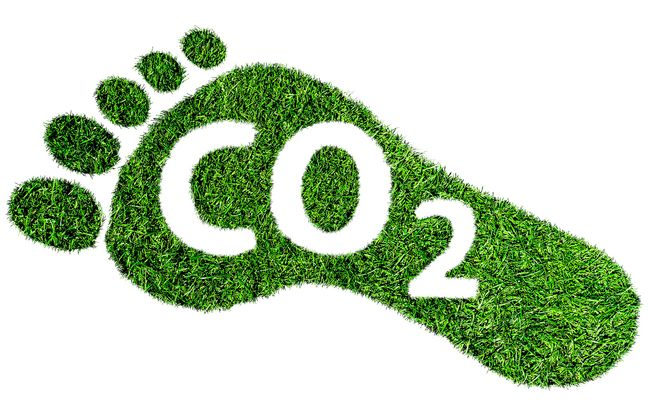

C02

That was our presentation, thank you so much.